# R_cnmf_vignette

This notebook provides example code for running cNMF on the standard PBMC example seurat counts matrix. Similar methodology can be used for other R object types, such as SingleCellExperiment. Generally, the counts matrix should be converted into a .mtx or .h5ad file (as shown below) for use in cnmf.

```r
suppressPackageStartupMessages({
    library(data.table)
    library(Matrix)
    library(Seurat)
})
```

First we download the standard pbmc3k example data used for Seura to a directory called ./R_Example_Data

```r
data_url <- 'https://cf.10xgenomics.com/samples/cell/pbmc3k/pbmc3k_filtered_gene_bc_matrices.tar.gz'
data_dir = './R_Example_Data/'

if (!dir.exists(data_dir)) {
  dir.create(data_dir, recursive = TRUE)
}

# Path where the tar.gz file will be saved
file_path <- file.path(data_dir, "pbmc3k_filtered_gene_bc_matrices.tar.gz")

# Download the file
download.file(data_url, file_path, mode="wb")
```

Then we extract the tar.gz file

```r
extract_command <- sprintf("tar -xzf %s -C %s", shQuote(file_path), shQuote(data_dir))
system(extract_command)

rm_command <- sprintf("rm %s", file_path)
system(rm_command)
```

Now the data should be stored locally

```r
system("ls ./R_Example_Data/filtered_gene_bc_matrices/hg19", intern=TRUE)
```

```
[1] "barcodes.tsv" "genes.tsv"    "matrix.mtx"
```

This data can actually be passed directly to cnmf as below. However, we recommend to filter genes detected in few cells and cells with few counts before running cnmf. We therefore do some filtering here first.

```r
pbmc.data <- Read10X(data.dir = "./R_Example_Data/filtered_gene_bc_matrices/hg19")
# Initialize the Seurat object with the raw (non-normalized data).
pbmc <- CreateSeuratObject(counts = pbmc.data, project = "pbmc3k", min.cells = 3, min.features = 200)
pbmc <- subset(pbmc, subset = nFeature_RNA > 200 & nCount_RNA > 200)
```

```r
dim(pbmc)
```

```
[1] 13714  2700
```

```r
counts <- pbmc@assays$RNA$counts
barcodes <- colnames(counts)
gene_names <- rownames(counts)
counts[1:5, 1:5]
```

```
5 x 5 sparse Matrix of class "dgCMatrix"
              AAACATACAACCAC-1 AAACATTGAGCTAC-1 AAACATTGATCAGC-1 AAACCGTGCTTCCG-1 AAACCGTGTATGCG-1
AL627309.1                   .                .                .                .                .
AP006222.2                   .                .                .                .                .
RP11-206L10.2                .                .                .                .                .
RP11-206L10.9                .                .                .                .                .
LINC00115                    .                .                .                .                .
```

```r
barcodes[1:5]
```

```
[1] "AAACATACAACCAC-1" "AAACATTGAGCTAC-1" "AAACATTGATCAGC-1" "AAACCGTGCTTCCG-1" "AAACCGTGTATGCG-1"
```

Now lets output the filtered matrix to disk.

```r
filtered_dir = './R_Example_Data/filtered/'

if (!dir.exists(filtered_dir)) {
  dir.create(filtered_dir, recursive = TRUE)
}

# Output counts matrix
writeMM(counts, paste0(filtered_dir, 'matrix.mtx'))
```

```r
# Output cell barcodes
barcodes <- colnames(counts)
write.table(as.data.frame(barcodes), paste0(filtered_dir, 'barcodes.tsv'),
           col.names = FALSE, row.names = FALSE, sep = "\t")


# Output feature names
gene_names <- rownames(counts)
features <- data.frame("gene_id" = gene_names,"gene_name" = gene_names,type = "Gene Expression")
write.table(as.data.frame(features), sep = "\t", paste0(filtered_dir, 'genes.tsv'),
           col.names = FALSE, row.names = FALSE)
```

Now we run cnmf by passing the command line commands to the system() function

First is the prepare step which normalizes the count matrix and prepares the factorization step

```r
runname = "example_cNMF"
cmd = paste("cnmf prepare --output-dir", data_dir,
            "--name", runname,
            "-c", paste0(filtered_dir, 'matrix.mtx'),
            "--max-nmf-iter 2000",
            "-k 5 6 7 8 9 10 --n-iter 20", sep=" ")
print(cmd)
```

```
[1] "cnmf prepare --output-dir ./R_Example_Data/ --name example_cNMF -c ./R_Example_Data/filtered/matrix.mtx --max-nmf-iter 2000 -k 5 6 7 8 9 10 --n-iter 20"
```

```r
system(cmd)
```

Next is the factorization step which runs NMF –n-iter times (in this case 20) for each value of K. In this tutorial we run all these jobs sequentially on a single worker but in theory this can be distributed to multiple cores or nodes with separate commands like so:

cnmf factorize –output-dir ./R_Example_Data/ –name example_cNMF –worker-index 0 –total-workers 3 cnmf factorize –output-dir ./R_Example_Data/ –name example_cNMF –worker-index 1 –total-workers 3 cnmf factorize –output-dir ./R_Example_Data/ –name example_cNMF –worker-index 2 –total-workers 3

```r
cmd = paste("cnmf factorize --output-dir", data_dir,
            "--name", runname,
            "--worker-index 0 --total-workers 1", sep=" ")
print(cmd)
```

```
[1] "cnmf factorize --output-dir ./R_Example_Data/ --name example_cNMF --worker-index 0 --total-workers 1"
```

```r
system(cmd)
```

[output not shown]

[output cut: 65 more lines]

```
[Worker 0]. Starting task 105.
[Worker 0]. Starting task 106.
[Worker 0]. Starting task 107.
[Worker 0]. Starting task 108.
[Worker 0]. Starting task 109.
[Worker 0]. Starting task 110.
[Worker 0]. Starting task 111.
[Worker 0]. Starting task 112.
[Worker 0]. Starting task 113.
[Worker 0]. Starting task 114.
[Worker 0]. Starting task 115.
[Worker 0]. Starting task 116.
[Worker 0]. Starting task 117.
[Worker 0]. Starting task 118.
[Worker 0]. Starting task 119.
```

Next we concatenate the results for each value of K into a single file

```r
cmd = paste("cnmf combine --output-dir", data_dir,
            "--name", runname, sep=" ")
print(cmd)
```

```
[1] "cnmf combine --output-dir ./R_Example_Data/ --name example_cNMF"
```

```r
system(cmd)
```

```
Combining factorizations for k=5.
Combining factorizations for k=6.
Combining factorizations for k=7.
Combining factorizations for k=8.
Combining factorizations for k=9.
Combining factorizations for k=10.
```

And make a plot estimating the trade-off between higher values of K and stability and error

```r
cmd = paste("cnmf k_selection_plot --output-dir", data_dir,
            "--name", runname, sep=" ")
print(cmd)
```

```
[1] "cnmf k_selection_plot --output-dir ./R_Example_Data/ --name example_cNMF"
```

```r
system(cmd)
```

We can load the saved png file to see the results in the Rmd notebook.

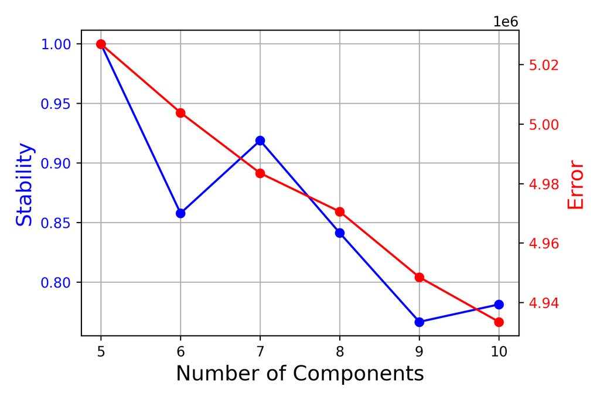

This plot suggests K=7 might be a local optimum in stability so lets try that solution.

```r
cmd = paste("cnmf consensus --output-dir", data_dir,
            "--name", runname,
            '--components', 7,
            '--local-density-threshold', 0.1,
            '--show-clustering', sep=" ")
print(cmd)
system(cmd)
```

This step creates a plot to help visualize the consensus clustering

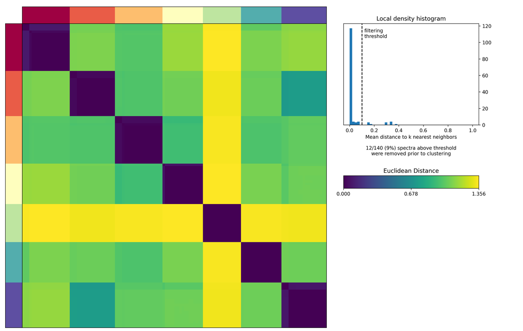

Looks like the clustering is very clean. Lets load in the resulting files.

```r
usage_file <- paste(data_dir[1:length(data_dir)], runname, paste(runname, "usages", "k_7.dt_0_1", 'consensus', 'txt', sep="."), sep="/")
spectra_score_file <- paste(data_dir[1:length(data_dir)], runname, paste(runname, "gene_spectra_score", "k_7.dt_0_1", 'txt', sep="."), sep="/")
spectra_tpm_file <- paste(data_dir[1:length(data_dir)], runname, paste(runname, "gene_spectra_tpm", "k_7.dt_0_1", 'txt', sep="."), sep="/")

usage <- read.table(usage_file, sep='\t', row.names=1, header=TRUE)
spectra_score <- read.table(spectra_score_file, sep='\t', row.names=1, header=TRUE)
spectra_tpm <- read.table(spectra_tpm_file, sep='\t', row.names=1, header=TRUE)
head(usage)
```

|  | X1 | X2 | X3 | X4 | X5 | X6 | X7 |
| --- | --- | --- | --- | --- | --- | --- | --- |
| AAACATACAACCAC-1 | 0.900971801 | 0.023971512 | 0.00000000 | 0.042196722 | 0.00000000 | 0.06761811 | 0.000000000 |
| AAACATTGAGCTAC-1 | 0.281912990 | 0.027619919 | 0.40953300 | 0.029475319 | 0.04005868 | 0.10677426 | 0.001426842 |
| AAACATTGATCAGC-1 | 0.897578174 | 0.007574193 | 0.00000000 | 0.035134141 | 0.06180369 | 0.09897488 | 0.006153193 |
| AAACCGTGCTTCCG-1 | 0.007435059 | 0.284141474 | 0.12161550 | 0.007799983 | 0.49205550 | 0.01866395 | 0.014228707 |
| AAACCGTGTATGCG-1 | 0.000000000 | 0.149062626 | 0.02631124 | 0.751641284 | 0.00000000 | 0.04348982 | 0.000000000 |
| AAACGCACTGGTAC-1 | 0.581158024 | 0.048460060 | 0.03074139 | 0.023662351 | 0.02231952 | 0.22598874 | 0.001306782 |

For most analyses we normalize the resulting usage file output so that each cell sums to 1. We do that below

```r
usage_norm <- as.data.frame(t(apply(usage, 1, function(x) x / sum(x))))
```

Now lets concatenate usage_norm into the metadata of the Seurat object to make it easier to plot later

```r
library(dplyr)
new_metadata <- merge(pbmc@meta.data, usage_norm, by = "row.names", all.x = TRUE)
rownames(new_metadata) <- new_metadata$Row.names
pbmc@meta.data <- new_metadata
```

Now lets run the standard Seurat UMAP pipeline so we can plot the GEP usages over the UMAP

```r
pbmc <- NormalizeData(pbmc, normalization.method = "LogNormalize", scale.factor = 10000)
```

```
Normalizing layer: counts
```

```r
pbmc <- FindVariableFeatures(pbmc, selection.method = "vst", nfeatures = 2000)
```

```
Finding variable features for layer counts
```

```r
all.genes <- rownames(pbmc)
pbmc <- ScaleData(pbmc, features = all.genes)
pbmc <- RunPCA(pbmc, features = VariableFeatures(object = pbmc))
```

```
PC_ 1
Positive:  MALAT1, LTB, IL32, CD2, ACAP1, STK17A, CTSW, CD247, CCL5, GIMAP5
       AQP3, GZMA, CST7, TRAF3IP3, MAL, HOPX, ITM2A, GZMK, MYC, BEX2
       GIMAP7, ETS1, LDLRAP1, ZAP70, LYAR, RIC3, TNFAIP8, KLRG1, SAMD3, NKG7
Negative:  CST3, TYROBP, LST1, AIF1, FTL, FCN1, LYZ, FTH1, S100A9, FCER1G
       TYMP, CFD, LGALS1, CTSS, S100A8, SERPINA1, LGALS2, SPI1, IFITM3, PSAP
       CFP, SAT1, IFI30, COTL1, S100A11, NPC2, LGALS3, GSTP1, PYCARD, NCF2
PC_ 2
Positive:  CD79A, MS4A1, TCL1A, HLA-DQA1, HLA-DRA, HLA-DQB1, LINC00926, CD79B, HLA-DRB1, CD74
       HLA-DPB1, HLA-DMA, HLA-DQA2, HLA-DRB5, HLA-DPA1, HLA-DMB, FCRLA, HVCN1, LTB, BLNK
       KIAA0125, P2RX5, IRF8, IGLL5, SWAP70, ARHGAP24, SMIM14, PPP1R14A, FCRL2, C16orf74
Negative:  NKG7, PRF1, CST7, GZMA, GZMB, FGFBP2, CTSW, GNLY, GZMH, SPON2
       CCL4, FCGR3A, CCL5, CD247, XCL2, CLIC3, AKR1C3, SRGN, HOPX, CTSC
       TTC38, S100A4, ANXA1, IL32, IGFBP7, ID2, ACTB, XCL1, APOBEC3G, SAMD3
PC_ 3
Positive:  HLA-DQA1, CD79A, CD79B, HLA-DQB1, HLA-DPB1, CD74, HLA-DPA1, MS4A1, HLA-DRB1, HLA-DRB5
       HLA-DRA, HLA-DQA2, TCL1A, LINC00926, HLA-DMB, HLA-DMA, HVCN1, FCRLA, IRF8, BLNK
       KIAA0125, SMIM14, PLD4, IGLL5, P2RX5, TMSB10, SWAP70, LAT2, MALAT1, IGJ
Negative:  PPBP, PF4, SDPR, SPARC, GNG11, NRGN, GP9, RGS18, TUBB1, CLU
       HIST1H2AC, AP001189.4, ITGA2B, CD9, TMEM40, CA2, PTCRA, ACRBP, MMD, TREML1
       NGFRAP1, F13A1, RUFY1, SEPT5, MPP1, CMTM5, TSC22D1, MYL9, RP11-367G6.3, GP1BA
PC_ 4
Positive:  HLA-DQA1, CD79A, CD79B, HIST1H2AC, HLA-DQB1, PF4, MS4A1, SDPR, CD74, PPBP
       HLA-DPB1, GNG11, HLA-DQA2, SPARC, HLA-DRB1, HLA-DPA1, GP9, TCL1A, HLA-DRA, LINC00926
       NRGN, RGS18, HLA-DRB5, PTCRA, CD9, AP001189.4, CA2, CLU, TUBB1, ITGA2B
Negative:  VIM, S100A8, S100A6, S100A4, S100A9, TMSB10, IL32, GIMAP7, LGALS2, S100A10
       RBP7, FCN1, MAL, LYZ, S100A12, MS4A6A, CD2, FYB, S100A11, FOLR3
       GIMAP4, AQP3, ANXA1, AIF1, MALAT1, GIMAP5, IL8, IFI6, TRABD2A, TMSB4X
PC_ 5
Positive:  GZMB, FGFBP2, NKG7, GNLY, PRF1, CCL4, CST7, SPON2, GZMA, CLIC3
       GZMH, XCL2, CTSW, TTC38, AKR1C3, CCL5, IGFBP7, XCL1, CCL3, S100A8
       TYROBP, HOPX, CD160, HAVCR2, S100A9, FCER1G, PTGDR, LGALS2, RBP7, S100A12
Negative:  LTB, VIM, AQP3, PPA1, MAL, KIAA0101, CD2, CYTIP, CORO1B, FYB
       IL32, TRADD, ANXA5, TUBA1B, HN1, TYMS, PTGES3, ITM2A, COTL1, GPR183
       TNFAIP8, ACTG1, TRAF3IP3, ATP5C1, GIMAP4, ZWINT, PRDX1, LDLRAP1, ABRACL, NGFRAP1
```

```r
pbmc <- FindNeighbors(pbmc, dims = 1:15)
pbmc <- RunUMAP(pbmc, dims = 1:15)
```

Now we can plot the usages of all of the GEPs on the UMAP

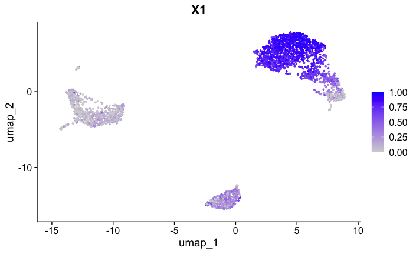

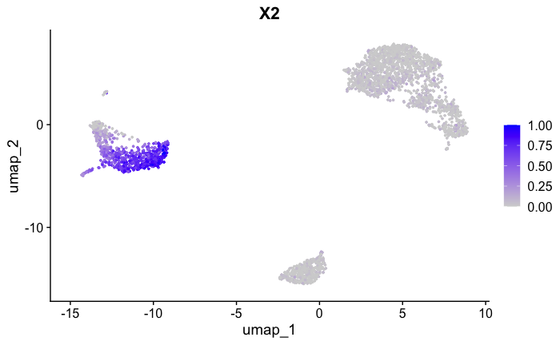

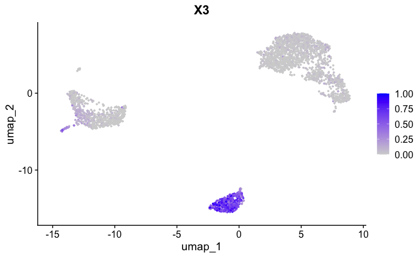

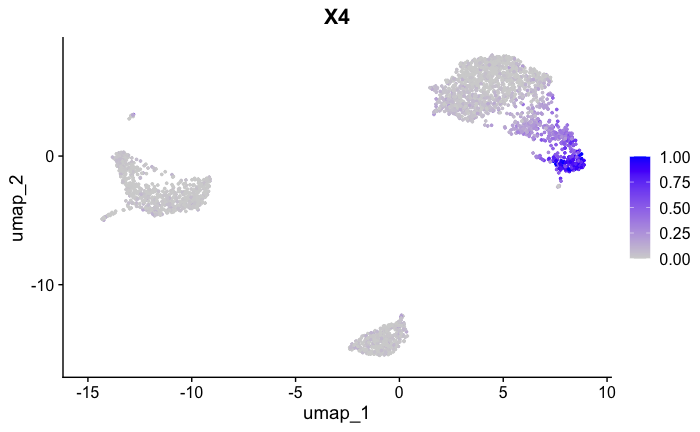

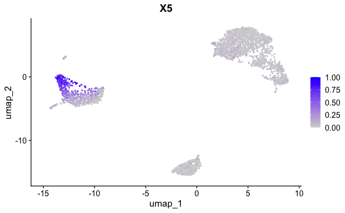

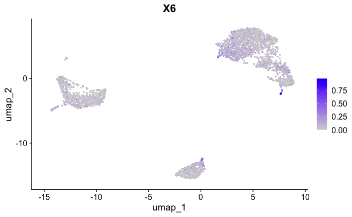

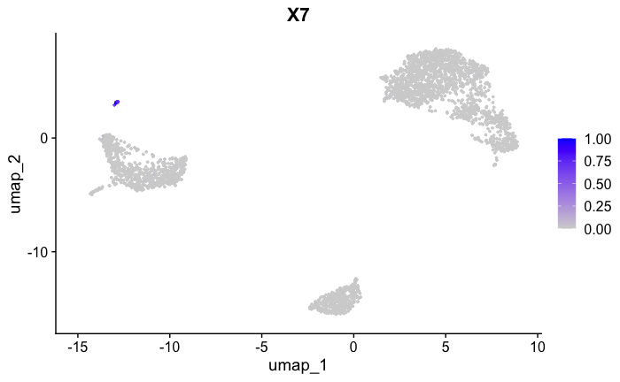

```r
library(ggplot2)
p <- FeaturePlot(pbmc, features = colnames(usage_norm), combine=F)
p
```

To help make sense of the learned GEPs, we extract the top 20 most highly weighted genes for each GEP as below.

```r
get_top_colnames <- function(row) {
  # Orders the values in descending order and gets the names of the top 20
  print(row[1:5])
  top_indices <- order(row, decreasing = TRUE)[1:20]
  return(colnames(spectra_score)[top_indices])
}

top_colnames <- apply(spectra_score, 1, get_top_colnames)
```

```
   AL627309.1    AP006222.2 RP11.206L10.2 RP11.206L10.9     LINC00115
-6.542395e-05  2.464484e-05 -5.362483e-05 -1.303773e-04 -5.269649e-05
   AL627309.1    AP006222.2 RP11.206L10.2 RP11.206L10.9     LINC00115
 5.820285e-04  1.144749e-04 -4.723043e-05  5.557517e-04  2.475056e-05
   AL627309.1    AP006222.2 RP11.206L10.2 RP11.206L10.9     LINC00115
-3.147999e-04 -1.375798e-04  9.899135e-04 -8.023409e-05  5.332880e-05
   AL627309.1    AP006222.2 RP11.206L10.2 RP11.206L10.9     LINC00115
-2.604781e-05 -7.780274e-06 -1.528840e-04 -1.174128e-04  2.073995e-04
   AL627309.1    AP006222.2 RP11.206L10.2 RP11.206L10.9     LINC00115
-2.203513e-04 -2.587423e-05 -1.039809e-04  1.618275e-04  1.711142e-05
   AL627309.1    AP006222.2 RP11.206L10.2 RP11.206L10.9     LINC00115
-2.415448e-05 -4.606496e-05 -3.921321e-05 -2.164424e-05 -2.388413e-05
   AL627309.1    AP006222.2 RP11.206L10.2 RP11.206L10.9     LINC00115
-1.903479e-05  2.433986e-06 -2.285056e-05 -5.491057e-05 -5.477156e-05
```

```r
top_colnames <- as.data.frame(top_colnames)

top_colnames
```

| 1 | 2 | 3 | 4 | 5 | 6 | 7 |
| --- | --- | --- | --- | --- | --- | --- |
| RPS12 | LYZ | CD74 | NKG7 | FCGR3A | RRM2 | C2orf88 |
| RPS27 | S100A9 | HLA.DRA | PRF1 | FCER1G | CDC6 | TSC22D1 |
| RPS25 | S100A8 | HLA.DQB1 | GZMB | LST1 | MCM10 | HIST1H2AC |
| EEF1A1 | CST3 | HLA.DQA1 | GZMA | RP11.290F20.3 | TYMS | AC147651.3 |
| RPS15A | CD14 | HLA.DPB1 | GNLY | MS4A7 | KIAA0101 | LGALSL |
| RPL31 | FCN1 | HLA.DRB1 | FGFBP2 | IFITM3 | CDC20 | ACRBP |
| RPS6 | TYROBP | CD79B | SPON2 | IFITM2 | TK1 | PTCRA |
| RPS27A | LGALS2 | HLA.DQA2 | CST7 | COTL1 | KIFC1 | MMD |
| RPLP2 | GSTP1 | MS4A1 | CTSW | RHOC | BIRC5 | ESAM |
| RPS3A | LGALS1 | HLA.DPA1 | CLIC3 | AIF1 | BLM | PRUNE |

[output cut: 10 more lines]

GEP 1 reflects T-cells, 2 reflects CD14 monocytes, 3 reflects B cells, 4 reflects NK cells, 5 reflects CD16 monocytes, 6 reflects cell cycle, 7 is less clear